# Tasa de abandono. Preprocesado

Samuel LP

En este proyecto piden realizar un análisis de la tasa de abandono de clientes de un banco y, mediante la aplicación de algunos algoritmos de aprendizaje automático (Machine Learning), sacar un modelo que explique dicha tasa de abandono en función del resto de variables.

Este notebook se centra en la visualización y análisis de variables, transformaciones y en el preprocesado.

# 1 LIBRERÍAS Y DATOS

Se cargan las librerías necesarias:

```r
suppressPackageStartupMessages({
  library(tidyverse)
  library(kableExtra)
  library(lares)
  library(inspectdf)
  library(funModeling)
  library(gmodels)
  library(flextable)
  library(dlookr)

 })
```

Los datos se pueden encontrar en Kaggle a través de [este enlace](https://www.kaggle.com/datasets/radheshyamkollipara/bank-customer-churn/data).

```r
data <- read_csv("data_original/churn.csv")

str(data)
```

```
## spc_tbl_ [10,000 × 18] (S3: spec_tbl_df/tbl_df/tbl/data.frame)
##  $ RowNumber         : num [1:10000] 1 2 3 4 5 6 7 8 9 10 ...
##  $ CustomerId        : num [1:10000] 15634602 15647311 15619304 15701354 15737888 ...
##  $ Surname           : chr [1:10000] "Hargrave" "Hill" "Onio" "Boni" ...
##  $ CreditScore       : num [1:10000] 619 608 502 699 850 645 822 376 501 684 ...
##  $ Geography         : chr [1:10000] "France" "Spain" "France" "France" ...
##  $ Gender            : chr [1:10000] "Female" "Female" "Female" "Female" ...
##  $ Age               : num [1:10000] 42 41 42 39 43 44 50 29 44 27 ...
##  $ Tenure            : num [1:10000] 2 1 8 1 2 8 7 4 4 2 ...
##  $ Balance           : num [1:10000] 0 83808 159661 0 125511 ...
##  $ NumOfProducts     : num [1:10000] 1 1 3 2 1 2 2 4 2 1 ...
##  $ HasCrCard         : num [1:10000] 1 0 1 0 1 1 1 1 0 1 ...
##  $ IsActiveMember    : num [1:10000] 1 1 0 0 1 0 1 0 1 1 ...
##  $ EstimatedSalary   : num [1:10000] 101349 112543 113932 93827 79084 ...
##  $ Exited            : num [1:10000] 1 0 1 0 0 1 0 1 0 0 ...
##  $ Complain          : num [1:10000] 1 1 1 0 0 1 0 1 0 0 ...
##  $ Satisfaction Score: num [1:10000] 2 3 3 5 5 5 2 2 3 3 ...
##  $ Card Type         : chr [1:10000] "DIAMOND" "DIAMOND" "DIAMOND" "GOLD" ...
##  $ Point Earned      : num [1:10000] 464 456 377 350 425 484 206 282 251 342 ...
##  - attr(*, "spec")=
##   .. cols(
##   ..   RowNumber = col_double(),
##   ..   CustomerId = col_double(),
##   ..   Surname = col_character(),
##   ..   CreditScore = col_double(),
##   ..   Geography = col_character(),
##   ..   Gender = col_character(),
##   ..   Age = col_double(),
##   ..   Tenure = col_double(),
##   ..   Balance = col_double(),
##   ..   NumOfProducts = col_double(),
##   ..   HasCrCard = col_double(),
##   ..   IsActiveMember = col_double(),
##   ..   EstimatedSalary = col_double(),
##   ..   Exited = col_double(),
##   ..   Complain = col_double(),
##   ..   `Satisfaction Score` = col_double(),
##   ..   `Card Type` = col_character(),
##   ..   `Point Earned` = col_double()
##   .. )
##  - attr(*, "problems")=<externalptr>
```

Son 10,000 observaciones (filas, clientes,…) y 18 variables llamadas:

```r
colnames(data)
```

```
##  [1] "RowNumber"          "CustomerId"         "Surname"
##  [4] "CreditScore"        "Geography"          "Gender"
##  [7] "Age"                "Tenure"             "Balance"
## [10] "NumOfProducts"      "HasCrCard"          "IsActiveMember"
## [13] "EstimatedSalary"    "Exited"             "Complain"
## [16] "Satisfaction Score" "Card Type"          "Point Earned"
```

Para simplificar se van a eliminar algunas variables que parecen irrelevantes para el problema. Estas variables son:

- RowNumber (indicativo de fila)
- CustomerId (identificativo del cliente)
- Surname (apellido del cliente)
- Complain (si hubo quejas o no)
- Satisfaction Score (puntuación sobre resolución de la queja)
- Card Type (tipo de tarjeta de crédito)
- Point Earned (puntos obtenido por usar la tarjeta de crédito)

Sería necesario un análisis más completo antes de desechar estas variables, pero no parecen que vayan a ayudar a explicar la salida de un cliente

Respecto a Complain, se ha desechado por ser similar a la variable objetivo (Exited) y por tanto ser una variable redundante. Se puede comprobar aquí:

```r
table(data$Exited, data$Complain)
```

```
##
##        0    1
##   0 7952   10
##   1    4 2034
```

Como se pude observar, casi el 100% de los clientes que emitieron una queja acabaron por abandonar el banco. Puede ser interesante mantener la variable en este apartado de visualización y preprocesado, pero no aportará nada relevante en la aplicación de modelos. En cualquier caso, se ha optado por eliminarla.

Aplicamos los cambios

```r
data <- data %>%
  select(-c(RowNumber, CustomerId, Surname, Complain, `Satisfaction Score`, `Card Type`, `Point Earned`))
```

Nuestras variables finales van a ser:

- CreditScore: solvencia del cliente.
- Geography: país
- Gender: género
- Age: edad
- Tenure: cuantos años ha estado el cliente con el banco
- Balance: cantidad actualmente disponible en la cuenta
- NumOfProduct: número de productos comprados a través del banco.
- HasCrCard: tiene una tarjeta de crédito o no
- IsActiveMember: miembro activo o inactivo.
- EstimatedSalary: estimación ingresos del cliente.
- Exited: indicador de si el cliente se ha ido o no del banco.

Hay variables que son categóricas, pero que se han cargado como numéricas o de tipo caracter. Se recodifican:

```r
data <- data %>%
  mutate(HasCrCard = as.factor(ifelse(HasCrCard == 1, "Yes", "No")),
         IsActiveMember = as.factor(ifelse(IsActiveMember == 1, "Yes", "No")),
        Exited = as.factor(ifelse(Exited == 1, "Yes", "No")),
        Geography = as.factor(Geography),
        Gender = as.factor(Gender))
```

Primeras filas del dataset:

```r
head(data) %>%
  kable("html") %>%
  kable_styling(bootstrap_options = c("bordered","condensed","responsive",'striped'),
                font_size = 14, full_width = F) %>%
  scroll_box(width = "100%")
```

| CreditScore | Geography | Gender | Age | Tenure | Balance | NumOfProducts | HasCrCard | IsActiveMember | EstimatedSalary | Exited |
| --- | --- | --- | --- | --- | --- | --- | --- | --- | --- | --- |
| 619 | France | Female | 42 | 2 | 0.00 | 1 | Yes | Yes | 101348.88 | Yes |
| 608 | Spain | Female | 41 | 1 | 83807.86 | 1 | No | Yes | 112542.58 | No |
| 502 | France | Female | 42 | 8 | 159660.80 | 3 | Yes | No | 113931.57 | Yes |
| 699 | France | Female | 39 | 1 | 0.00 | 2 | No | No | 93826.63 | No |
| 850 | Spain | Female | 43 | 2 | 125510.82 | 1 | Yes | Yes | 79084.10 | No |
| 645 | Spain | Male | 44 | 8 | 113755.78 | 2 | Yes | No | 149756.71 | Yes |

Estructura final:

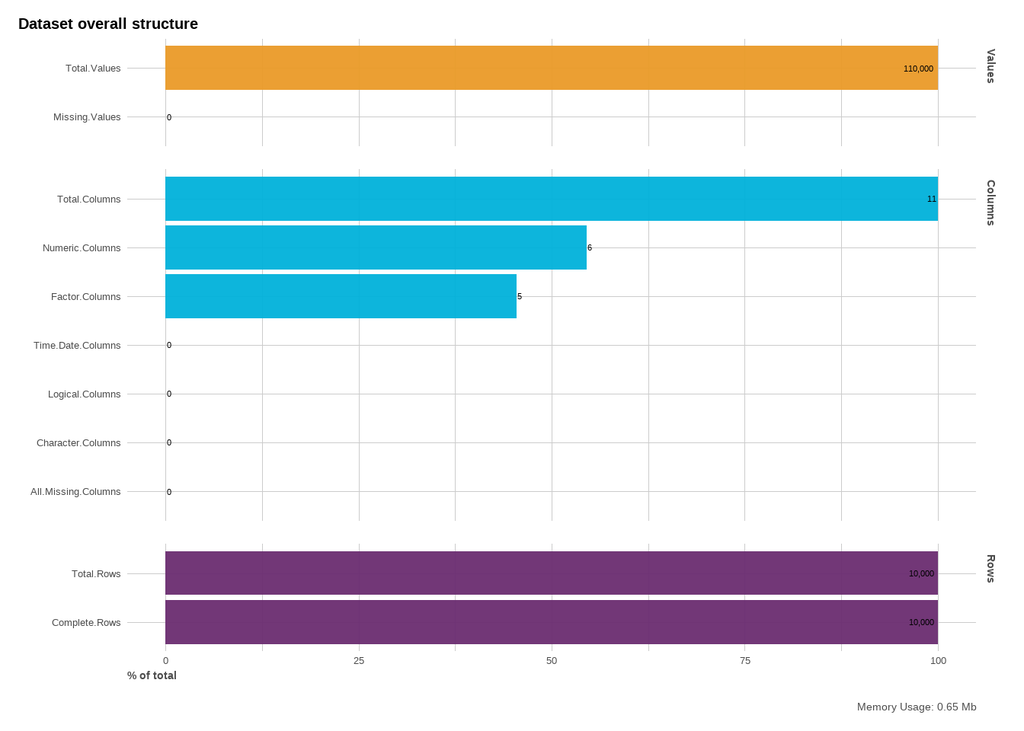

```r
df_str(data, return = "plot")
```

# 2 ANÁLISIS DESCRIPTIVO Y SUMARIOS ESTADÍSTICOS

```r
summary(data)
```

```
##   CreditScore      Geography       Gender          Age            Tenure
##  Min.   :350.0   France :5014   Female:4543   Min.   :18.00   Min.   : 0.000
##  1st Qu.:584.0   Germany:2509   Male  :5457   1st Qu.:32.00   1st Qu.: 3.000
##  Median :652.0   Spain  :2477                 Median :37.00   Median : 5.000
##  Mean   :650.5                                Mean   :38.92   Mean   : 5.013
##  3rd Qu.:718.0                                3rd Qu.:44.00   3rd Qu.: 7.000
##  Max.   :850.0                                Max.   :92.00   Max.   :10.000
##     Balance       NumOfProducts  HasCrCard  IsActiveMember EstimatedSalary
##  Min.   :     0   Min.   :1.00   No :2945   No :4849       Min.   :    11.58
##  1st Qu.:     0   1st Qu.:1.00   Yes:7055   Yes:5151       1st Qu.: 51002.11
##  Median : 97199   Median :1.00                             Median :100193.91
##  Mean   : 76486   Mean   :1.53                             Mean   :100090.24
##  3rd Qu.:127644   3rd Qu.:2.00                             3rd Qu.:149388.25
##  Max.   :250898   Max.   :4.00                             Max.   :199992.48
##  Exited
##  No :7962
##  Yes:2038
##
##
##
##
```

```r
df_status(data)
```

```
##           variable q_zeros p_zeros q_na p_na q_inf p_inf    type unique
## 1      CreditScore       0    0.00    0    0     0     0 numeric    460
## 2        Geography       0    0.00    0    0     0     0  factor      3
## 3           Gender       0    0.00    0    0     0     0  factor      2
## 4              Age       0    0.00    0    0     0     0 numeric     70
## 5           Tenure     413    4.13    0    0     0     0 numeric     11
## 6          Balance    3617   36.17    0    0     0     0 numeric   6382
## 7    NumOfProducts       0    0.00    0    0     0     0 numeric      4
## 8        HasCrCard       0    0.00    0    0     0     0  factor      2
## 9   IsActiveMember       0    0.00    0    0     0     0  factor      2
## 10 EstimatedSalary       0    0.00    0    0     0     0 numeric   9999
## 11          Exited       0    0.00    0    0     0     0  factor      2
```

# 3 VALORES AUSENTES Y REPETIDOS

A través de otras funciones se ha visto que no existen valores ausentes. Se vuelve a comprobar:

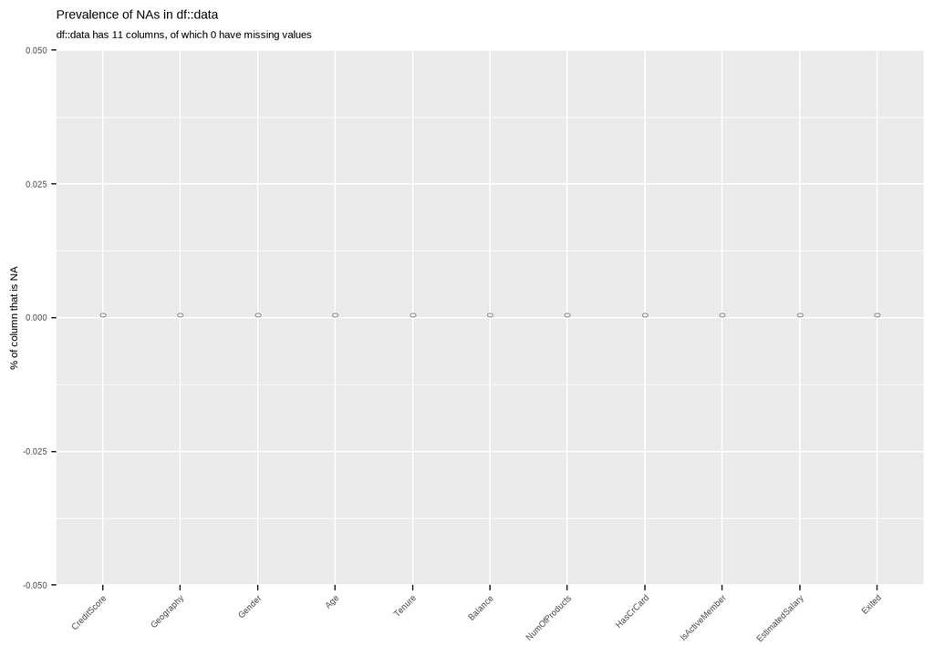

```r
show_plot(inspect_na(data))
```

No hay valores ausentes

También se comprueba que no haya valores repetidos (duplicados)

```r
sum(duplicated(data))
```

```
## [1] 0
```

No hay filas duplicadas

# 4 ANÁLISIS DE VARIABLES

En este apartado se analizan individualmente las variables separando variables numéricas de variables categóricas.

## 4.1 VARIABLES NUMÉRICAS

La función profiling_num selecciona automáticamente las variables numéricas y ofrece algnas estadísticas de interés como media, desviación, coeficiente de varianción, percentiles, asimetría, cúrtosis, etc…

```r
profiling_num(data)
```

```
##          variable        mean      std_dev variation_coef     p_01     p_05
## 1     CreditScore    650.5288 9.665330e+01      0.1485765  432.000  489.000
## 2             Age     38.9218 1.048781e+01      0.2694584   21.000   25.000
## 3          Tenure      5.0128 2.892174e+00      0.5769579    0.000    1.000
## 4         Balance  76485.8893 6.239741e+04      0.8158028    0.000    0.000
## 5   NumOfProducts      1.5302 5.816544e-01      0.3801166    1.000    1.000
## 6 EstimatedSalary 100090.2399 5.751049e+04      0.5745864 1842.825 9851.819
##       p_25      p_50     p_75     p_95     p_99     skewness kurtosis       iqr
## 1   584.00    652.00    718.0    812.0    850.0 -0.071595867 2.573887    134.00
## 2    32.00     37.00     44.0     60.0     72.0  1.011168559 4.394050     12.00
## 3     3.00      5.00      7.0      9.0     10.0  0.010989809 1.834757      4.00
## 4     0.00  97198.54 127644.2 162711.7 185968.0 -0.141087544 1.510733 127644.24
## 5     1.00      1.00      2.0      2.0      3.0  0.745456048 3.582089      1.00
## 6 51002.11 100193.91 149388.2 190155.4 198069.7  0.002085045 1.818472  98386.14
##                   range_98               range_80
## 1               [432, 850]             [521, 778]
## 2                 [21, 72]               [27, 53]
## 3                  [0, 10]                 [1, 9]
## 4         [0, 185967.9854]        [0, 149244.792]
## 5                   [1, 3]                 [1, 2]
## 6 [1842.8253, 198069.7345] [20273.58, 179674.704]
```

A continuación se crean boxplots cruzando las variables numéricas con la variable objetivo (Exited). La función plotar lo hace con una linea de código

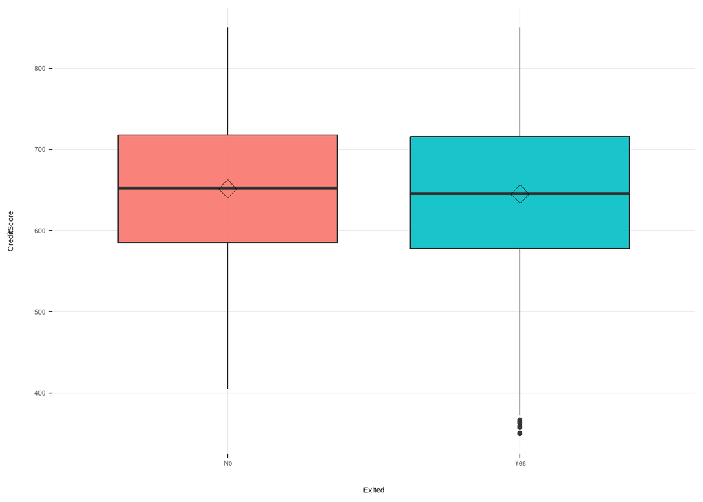

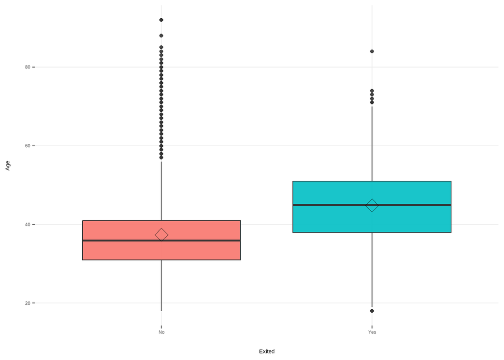

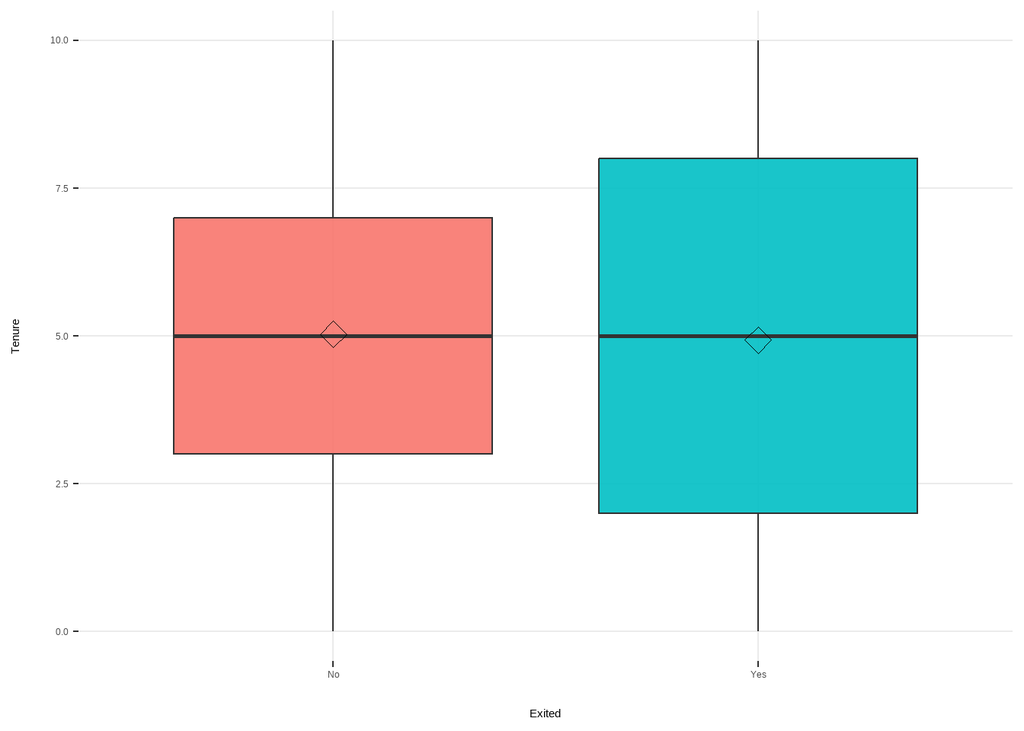

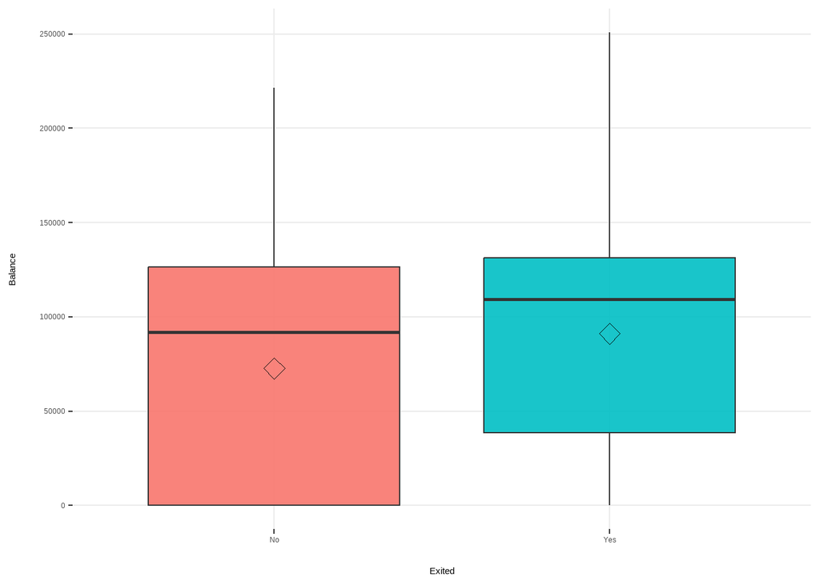

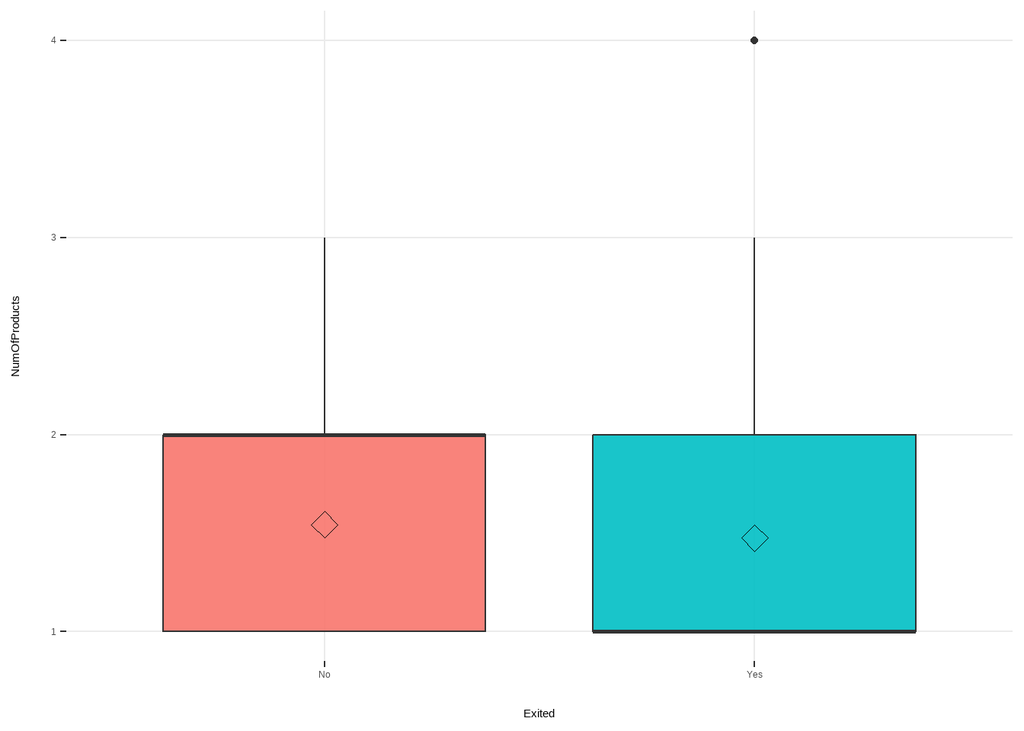

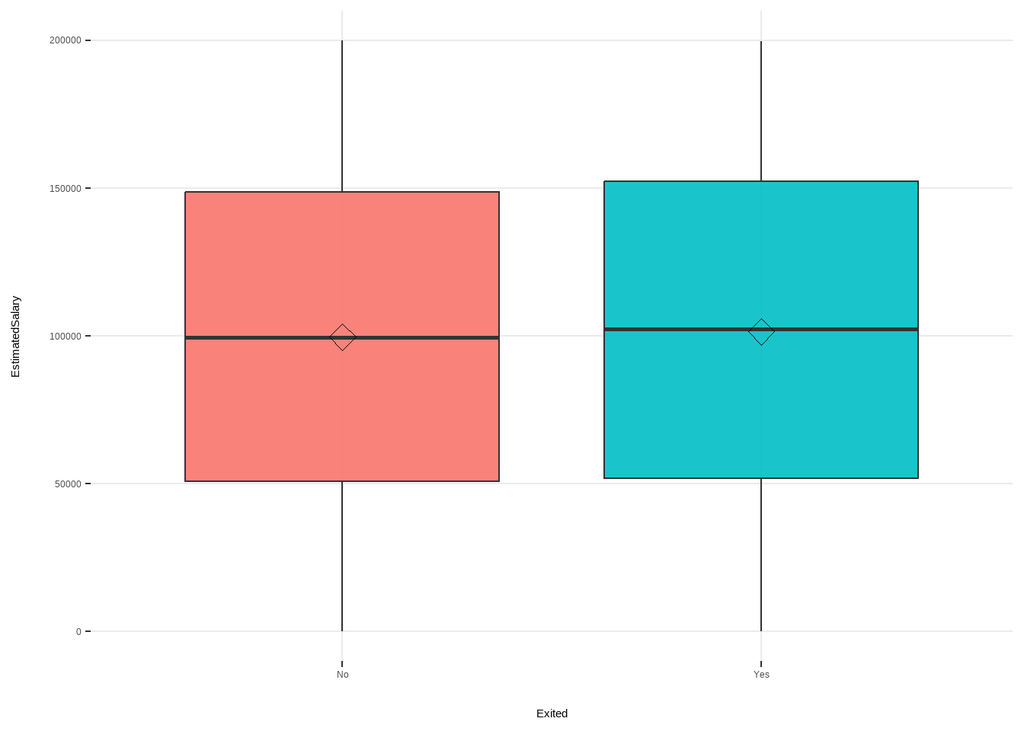

```r
plotar(data, target= "Exited", plot_type="boxplot")
```

Parece haber diferencias en el comportamiento de algunas variables en función de los valores de la variable exited. Comprobamos si esas diferencias son significativas a través del test de Levene y del test T

```r
car::leveneTest(CreditScore ~ Exited, data = data, center = "median")
```

```
## Levene's Test for Homogeneity of Variance (center = "median")
##         Df F value  Pr(>F)
## group    1  5.6166 0.01781 *
##       9998
## ---
## Signif. codes:  0 '***' 0.001 '**' 0.01 '*' 0.05 '.' 0.1 ' ' 1
```

Con un p-valor menor que 0.05 se puede deducir que hay evidencia significativa para rechazar la hipótesis nula de igualdad de varianza. El siguiente paso es comprobar lo mismo para la igualdad de medias con t.test()

```r
t.test(CreditScore ~ Exited, data = data,var.equal = FALSE )
```

```
##
##  Welch Two Sample t-test
##
## data:  CreditScore by Exited
## t = 2.603, df = 3052.6, p-value = 0.009285
## alternative hypothesis: true difference in means between group No and group Yes is not equal to 0
## 95 percent confidence interval:
##   1.584924 11.261541
## sample estimates:
##  mean in group No mean in group Yes
##          651.8379          645.4146
```

De nuevo podemos rechazar la hipótesis de igualdad de medias (p-valor = 0.009).

Se comprueban el resto de variables:

```r
car::leveneTest(Age ~ Exited, data = data, center = "median")
```

```
## Levene's Test for Homogeneity of Variance (center = "median")
##         Df F value    Pr(>F)
## group    1  12.968 0.0003183 ***
##       9998
## ---
## Signif. codes:  0 '***' 0.001 '**' 0.01 '*' 0.05 '.' 0.1 ' ' 1
```

```r
t.test(Age ~ Exited, data = data,var.equal = FALSE )
```

```
##
##  Welch Two Sample t-test
##
## data:  Age by Exited
## t = -30.42, df = 3251, p-value < 2.2e-16
## alternative hypothesis: true difference in means between group No and group Yes is not equal to 0
## 95 percent confidence interval:
##  -7.906292 -6.948828
## sample estimates:
##  mean in group No mean in group Yes
##          37.40806          44.83562
```

```r
car::leveneTest(Tenure ~ Exited, data = data, center = "median")
```

```
## Levene's Test for Homogeneity of Variance (center = "median")
##         Df F value Pr(>F)
## group    1  1.5636 0.2112
##       9998
```

```r
t.test(Tenure ~ Exited, data = data,var.equal = FALSE )
```

```
##
##  Welch Two Sample t-test
##
## data:  Tenure by Exited
## t = 1.35, df = 3115.4, p-value = 0.1771
## alternative hypothesis: true difference in means between group No and group Yes is not equal to 0
## 95 percent confidence interval:
##  -0.04435171  0.24043325
## sample estimates:
##  mean in group No mean in group Yes
##          5.032781          4.934740
```

```r
car::leveneTest(Balance ~ Exited, data = data, center = "median")
```

```
## Levene's Test for Homogeneity of Variance (center = "median")
##         Df F value    Pr(>F)
## group    1  148.83 < 2.2e-16 ***
##       9998
## ---
## Signif. codes:  0 '***' 0.001 '**' 0.01 '*' 0.05 '.' 0.1 ' ' 1
```

```r
t.test(Balance ~ Exited, data = data,var.equal = FALSE )
```

```
##
##  Welch Two Sample t-test
##
## data:  Balance by Exited
## t = -12.478, df = 3351.1, p-value < 2.2e-16
## alternative hypothesis: true difference in means between group No and group Yes is not equal to 0
## 95 percent confidence interval:
##  -21252.69 -15480.76
## sample estimates:
##  mean in group No mean in group Yes
##          72742.75          91109.48
```

```r
car::leveneTest(EstimatedSalary ~ Exited, data = data, center = "median")
```

```
## Levene's Test for Homogeneity of Variance (center = "median")
##         Df F value Pr(>F)
## group    1  0.9848 0.3211
##       9998
```

```r
t.test(EstimatedSalary ~ Exited, data = data,var.equal = FALSE )
```

```
##
##  Welch Two Sample t-test
##
## data:  EstimatedSalary by Exited
## t = -1.2421, df = 3138.6, p-value = 0.2143
## alternative hypothesis: true difference in means between group No and group Yes is not equal to 0
## 95 percent confidence interval:
##  -4597.639  1031.527
## sample estimates:
##  mean in group No mean in group Yes
##          99726.85         101509.91
```

```r
car::leveneTest(NumOfProducts ~ Exited, data = data, center = "median")
```

```
## Levene's Test for Homogeneity of Variance (center = "median")
##         Df F value Pr(>F)
## group    1  0.3252 0.5685
##       9998
```

```r
t.test(NumOfProducts ~ Exited, data = data,var.equal = FALSE )
```

```
##
##  Welch Two Sample t-test
##
## data:  NumOfProducts by Exited
## t = 3.6864, df = 2473.6, p-value = 0.0002324
## alternative hypothesis: true difference in means between group No and group Yes is not equal to 0
## 95 percent confidence interval:
##  0.0321765 0.1053112
## sample estimates:
##  mean in group No mean in group Yes
##          1.544210          1.475466
```

En este primer análisis se puede ver que credit score, balance y age son variables significativas.

Finalmente se ven los histogramas para ver la distribución de las variables

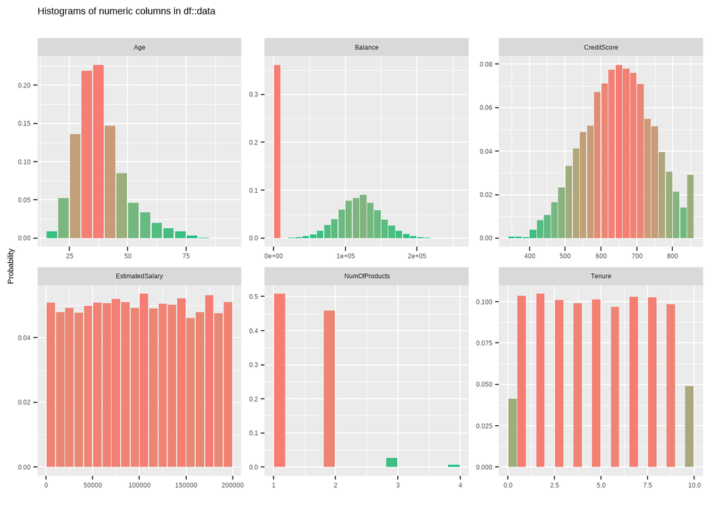

```r
show_plot(inspect_num(data))
```

## 4.2 VARIABLES CATEGÓRICAS

Se comprueban ahora las variables categóricas

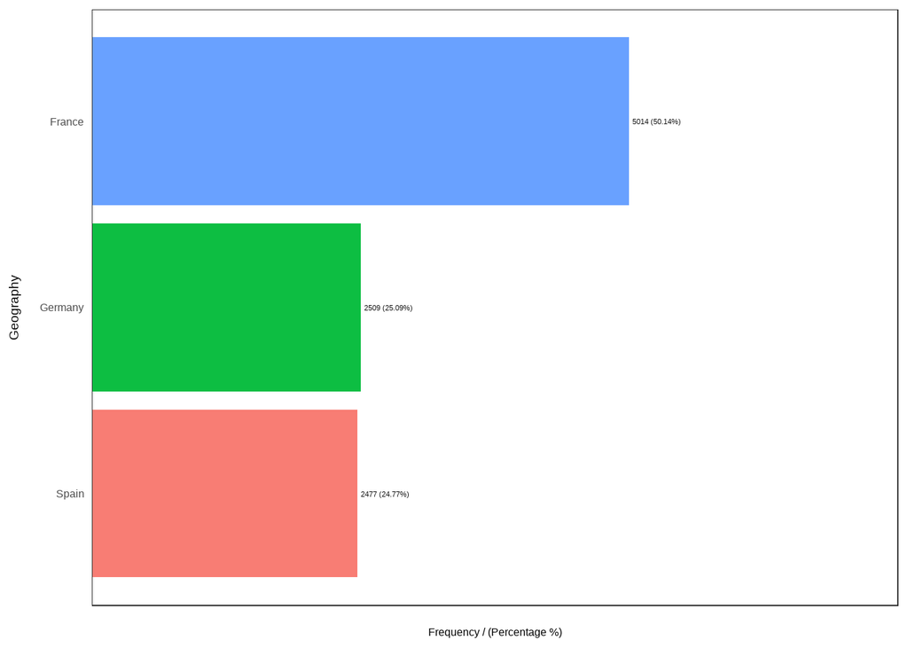

```
##   Geography frequency percentage cumulative_perc
## 1    France      5014      50.14           50.14
## 2   Germany      2509      25.09           75.23
## 3     Spain      2477      24.77          100.00
```

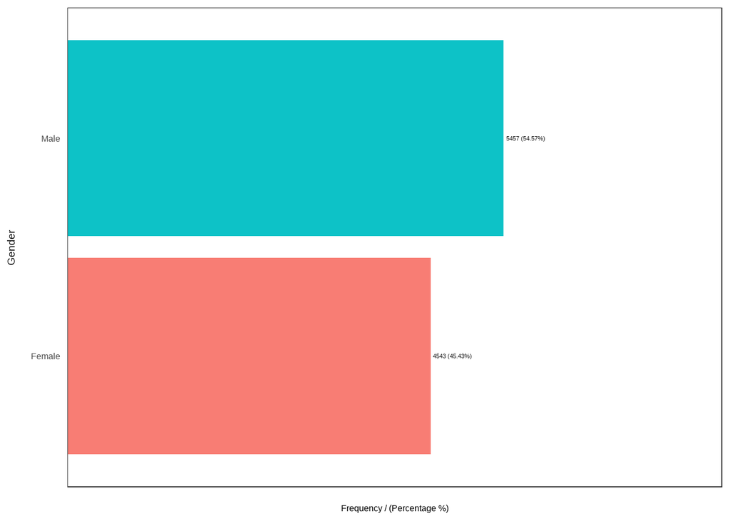

```
##   Gender frequency percentage cumulative_perc
## 1   Male      5457      54.57           54.57
## 2 Female      4543      45.43          100.00
```

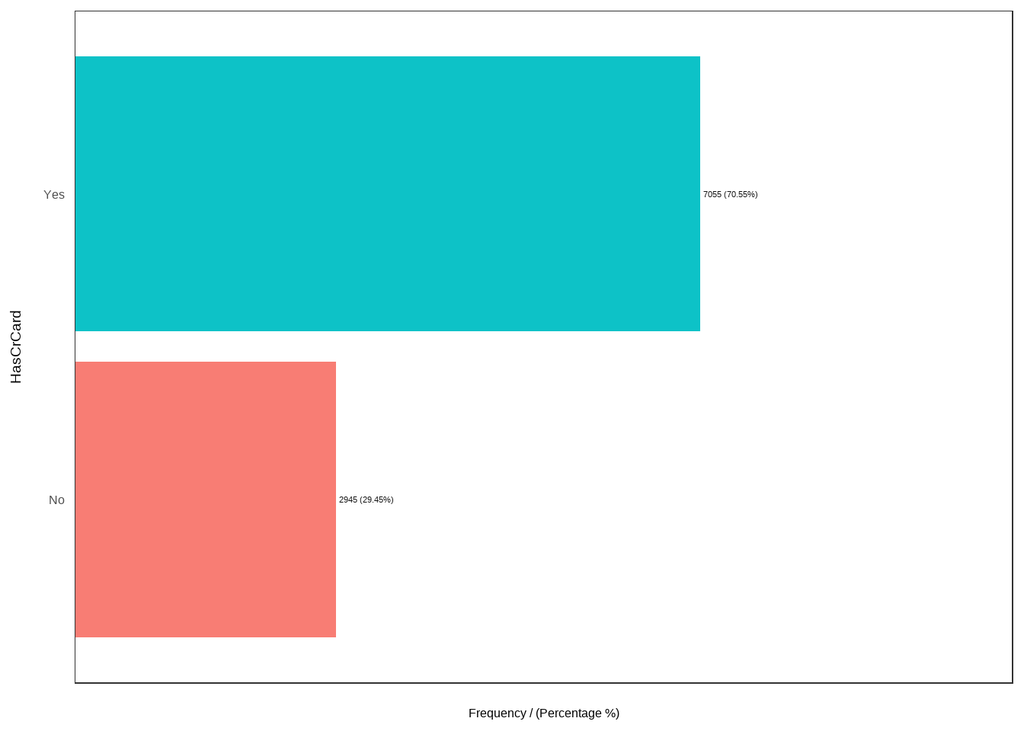

```
##   HasCrCard frequency percentage cumulative_perc
## 1       Yes      7055      70.55           70.55
## 2        No      2945      29.45          100.00
```

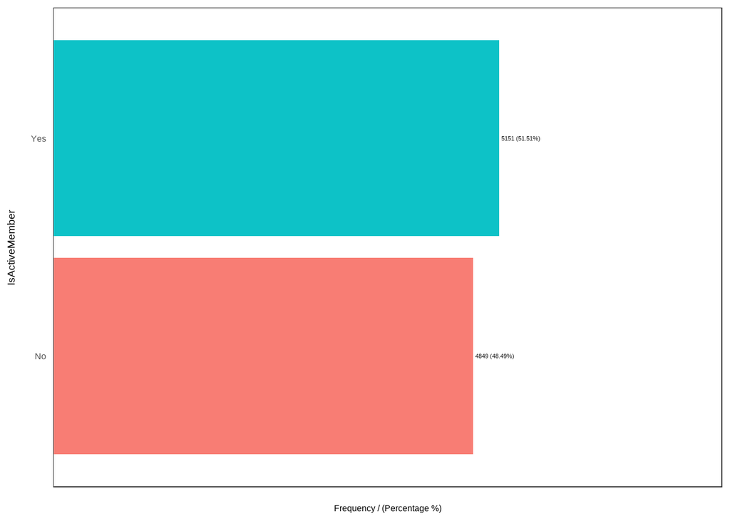

```
##   IsActiveMember frequency percentage cumulative_perc
## 1            Yes      5151      51.51           51.51
## 2             No      4849      48.49          100.00
```

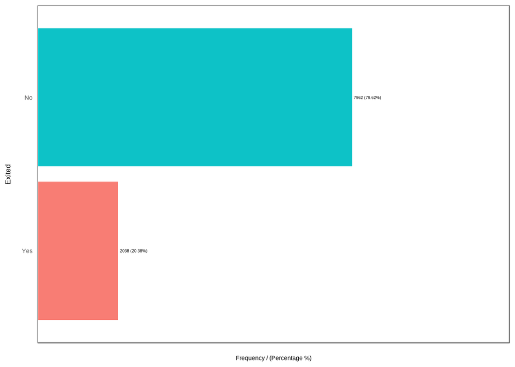

```
##   Exited frequency percentage cumulative_perc
## 1     No      7962      79.62           79.62
## 2    Yes      2038      20.38          100.00
```

```
## [1] "Variables processed: Geography, Gender, HasCrCard, IsActiveMember, Exited"
```

```r
freq(data)
```

Se puede ver que la variable objetivo Exited no está especialmente desbalanceada (80/20).

Se cruzan estas variables con la variable objetivo

```r
categoricas <- data %>%
  select(where(is.factor))


categ_analysis(categoricas, target = 'Exited')
```

```
##   Geography mean_target sum_target perc_target q_rows perc_rows
## 1   Germany       0.324        814       0.399   2509     0.251
## 2     Spain       0.167        413       0.203   2477     0.248
## 3    France       0.162        811       0.398   5014     0.501
##
##   Gender mean_target sum_target perc_target q_rows perc_rows
## 1 Female       0.251       1139       0.559   4543     0.454
## 2   Male       0.165        899       0.441   5457     0.546
##
##   HasCrCard mean_target sum_target perc_target q_rows perc_rows
## 1        No       0.208        613       0.301   2945     0.294
## 2       Yes       0.202       1425       0.699   7055     0.706
##
##   IsActiveMember mean_target sum_target perc_target q_rows perc_rows
## 1             No       0.269       1303       0.639   4849     0.485
## 2            Yes       0.143        735       0.361   5151     0.515
```

```
## [1] "Variables processed: Geography, Gender, HasCrCard, IsActiveMember"
```

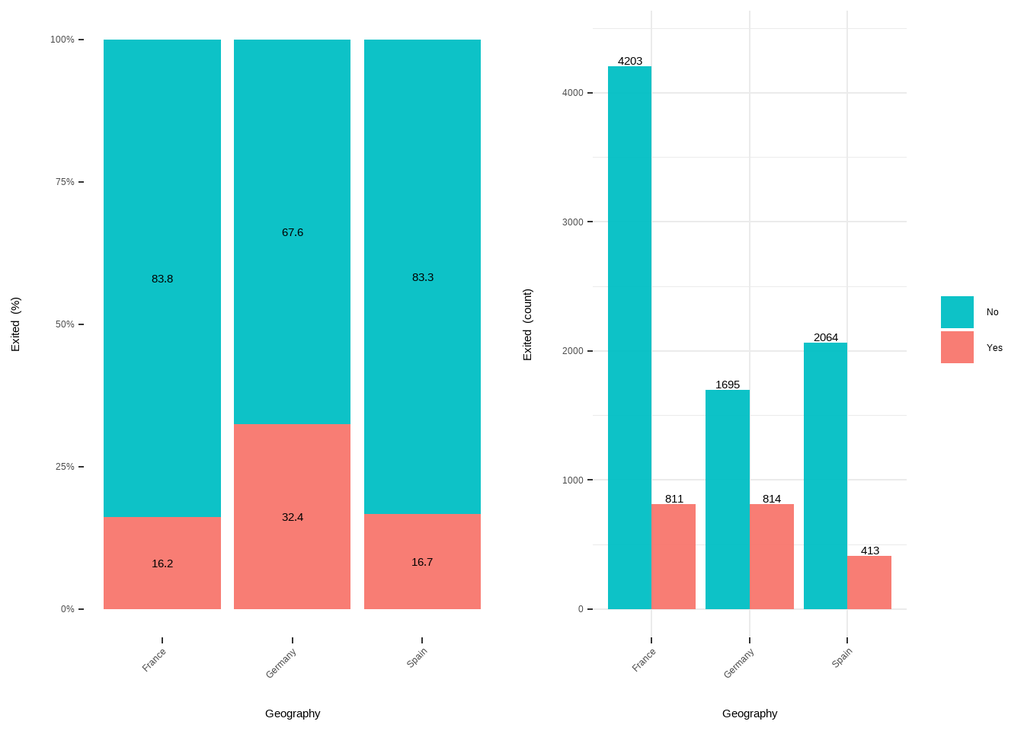

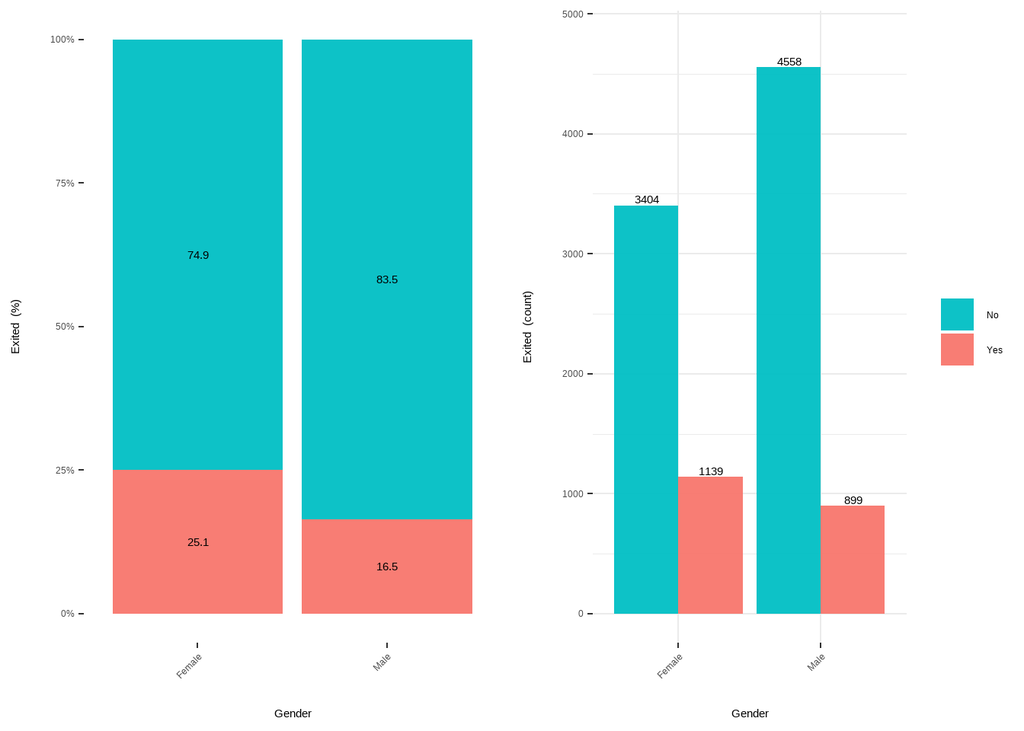

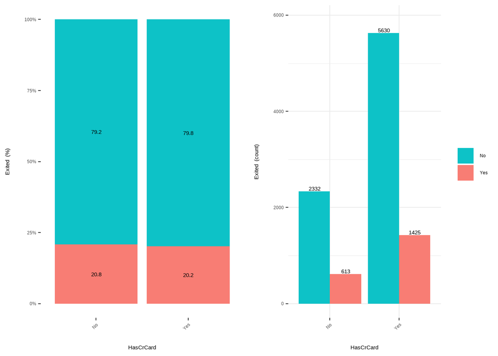

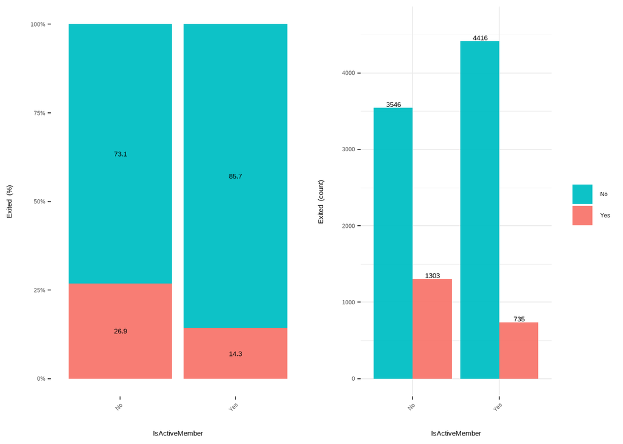

```r
cross_plot(categoricas, target = 'Exited', auto_binning = TRUE )
```

Para ver si existe un grado de asociación significativo entre variables categóricas y la variable objetivo se puede hacer un test de contingencia

Este test nos permite comprobar el grado de asociación entre variables

```r
CrossTable(data$Geography,data$Exited, expected = TRUE, format="SPSS")
```

```
##
##    Cell Contents
## |-------------------------|
## |                   Count |
## |         Expected Values |
## | Chi-square contribution |
## |             Row Percent |
## |          Column Percent |
## |           Total Percent |
## |-------------------------|
##
## Total Observations in Table:  10000
##
##                | data$Exited
## data$Geography |       No  |      Yes  | Row Total |
## ---------------|-----------|-----------|-----------|
##         France |     4203  |      811  |     5014  |
##                | 3992.147  | 1021.853  |           |
##                |   11.137  |   43.508  |           |
##                |   83.825% |   16.175% |   50.140% |
##                |   52.788% |   39.794% |           |
##                |   42.030% |    8.110% |           |
## ---------------|-----------|-----------|-----------|
##        Germany |     1695  |      814  |     2509  |
##                | 1997.666  |  511.334  |           |
##                |   45.857  |  179.152  |           |
##                |   67.557% |   32.443% |   25.090% |
##                |   21.289% |   39.941% |           |
##                |   16.950% |    8.140% |           |
## ---------------|-----------|-----------|-----------|
##          Spain |     2064  |      413  |     2477  |
##                | 1972.187  |  504.813  |           |
##                |    4.274  |   16.698  |           |
##                |   83.327% |   16.673% |   24.770% |
##                |   25.923% |   20.265% |           |
##                |   20.640% |    4.130% |           |
## ---------------|-----------|-----------|-----------|
##   Column Total |     7962  |     2038  |    10000  |
##                |   79.620% |   20.380% |           |
## ---------------|-----------|-----------|-----------|
##
##
## Statistics for All Table Factors
##
##
## Pearson's Chi-squared test
## ------------------------------------------------------------
## Chi^2 =  300.6264     d.f. =  2     p =  5.245736e-66
##
##
##
##        Minimum expected frequency: 504.8126
```

Al ser el p-value menor que 0,05 (nivel de significación elegido), la conclusión que se extrae es que no son independientes, es decir, se puede afirmar que existe cierto grado de asociación entre el país donde se realizan las operaciones financieras y la fuga de clientes

Repetimos el test con el resto de variables:

```r
CrossTable(data$Gender,data$Exited, expected = TRUE, format="SPSS")
```

```
##
##    Cell Contents
## |-------------------------|
## |                   Count |
## |         Expected Values |
## | Chi-square contribution |
## |             Row Percent |
## |          Column Percent |
## |           Total Percent |
## |-------------------------|
##
## Total Observations in Table:  10000
##
##              | data$Exited
##  data$Gender |       No  |      Yes  | Row Total |
## -------------|-----------|-----------|-----------|
##       Female |     3404  |     1139  |     4543  |
##              | 3617.137  |  925.863  |           |
##              |   12.559  |   49.065  |           |
##              |   74.928% |   25.072% |   45.430% |
##              |   42.753% |   55.888% |           |
##              |   34.040% |   11.390% |           |
## -------------|-----------|-----------|-----------|
##         Male |     4558  |      899  |     5457  |
##              | 4344.863  | 1112.137  |           |
##              |   10.455  |   40.847  |           |
##              |   83.526% |   16.474% |   54.570% |
##              |   57.247% |   44.112% |           |
##              |   45.580% |    8.990% |           |
## -------------|-----------|-----------|-----------|
## Column Total |     7962  |     2038  |    10000  |
##              |   79.620% |   20.380% |           |
## -------------|-----------|-----------|-----------|
##
##
## Statistics for All Table Factors
##
##
## Pearson's Chi-squared test
## ------------------------------------------------------------
## Chi^2 =  112.9258     d.f. =  1     p =  2.240072e-26
##
## Pearson's Chi-squared test with Yates' continuity correction
## ------------------------------------------------------------
## Chi^2 =  112.3966     d.f. =  1     p =  2.925368e-26
##
##
##        Minimum expected frequency: 925.8634
```

```r
CrossTable(data$HasCrCard,data$Exited, expected = TRUE, format="SPSS")
```

```
##
##    Cell Contents
## |-------------------------|
## |                   Count |
## |         Expected Values |
## | Chi-square contribution |
## |             Row Percent |
## |          Column Percent |
## |           Total Percent |
## |-------------------------|
##
## Total Observations in Table:  10000
##
##                | data$Exited
## data$HasCrCard |       No  |      Yes  | Row Total |
## ---------------|-----------|-----------|-----------|
##             No |     2332  |      613  |     2945  |
##                | 2344.809  |  600.191  |           |
##                |    0.070  |    0.273  |           |
##                |   79.185% |   20.815% |   29.450% |
##                |   29.289% |   30.079% |           |
##                |   23.320% |    6.130% |           |
## ---------------|-----------|-----------|-----------|
##            Yes |     5630  |     1425  |     7055  |
##                | 5617.191  | 1437.809  |           |
##                |    0.029  |    0.114  |           |
##                |   79.802% |   20.198% |   70.550% |
##                |   70.711% |   69.921% |           |
##                |   56.300% |   14.250% |           |
## ---------------|-----------|-----------|-----------|
##   Column Total |     7962  |     2038  |    10000  |
##                |   79.620% |   20.380% |           |
## ---------------|-----------|-----------|-----------|
##
##
## Statistics for All Table Factors
##
##
## Pearson's Chi-squared test
## ------------------------------------------------------------
## Chi^2 =  0.4866557     d.f. =  1     p =  0.4854229
##
## Pearson's Chi-squared test with Yates' continuity correction
## ------------------------------------------------------------
## Chi^2 =  0.4494039     d.f. =  1     p =  0.5026182
##
##
##        Minimum expected frequency: 600.191
```

```r
CrossTable(data$IsActiveMember,data$Exited, expected = TRUE, format="SPSS")
```

```
##
##    Cell Contents
## |-------------------------|
## |                   Count |
## |         Expected Values |
## | Chi-square contribution |
## |             Row Percent |
## |          Column Percent |
## |           Total Percent |
## |-------------------------|
##
## Total Observations in Table:  10000
##
##                     | data$Exited
## data$IsActiveMember |       No  |      Yes  | Row Total |
## --------------------|-----------|-----------|-----------|
##                  No |     3546  |     1303  |     4849  |
##                     | 3860.774  |  988.226  |           |
##                     |   25.664  |  100.263  |           |
##                     |   73.128% |   26.872% |   48.490% |
##                     |   44.537% |   63.935% |           |
##                     |   35.460% |   13.030% |           |
## --------------------|-----------|-----------|-----------|
##                 Yes |     4416  |      735  |     5151  |
##                     | 4101.226  | 1049.774  |           |
##                     |   24.159  |   94.385  |           |
##                     |   85.731% |   14.269% |   51.510% |
##                     |   55.463% |   36.065% |           |
##                     |   44.160% |    7.350% |           |
## --------------------|-----------|-----------|-----------|
##        Column Total |     7962  |     2038  |    10000  |
##                     |   79.620% |   20.380% |           |
## --------------------|-----------|-----------|-----------|
##
##
## Statistics for All Table Factors
##
##
## Pearson's Chi-squared test
## ------------------------------------------------------------
## Chi^2 =  244.4708     d.f. =  1     p =  4.167726e-55
##
## Pearson's Chi-squared test with Yates' continuity correction
## ------------------------------------------------------------
## Chi^2 =  243.6948     d.f. =  1     p =  6.153167e-55
##
##
##        Minimum expected frequency: 988.2262
```

Conclusiones: existe cierto grado de asociación entre la variable objetivo (Exited) y Geography, Gender y IsActiveMember

# 5 CORRELACIÓN

Se comprueba la correlación entre variables numéricas

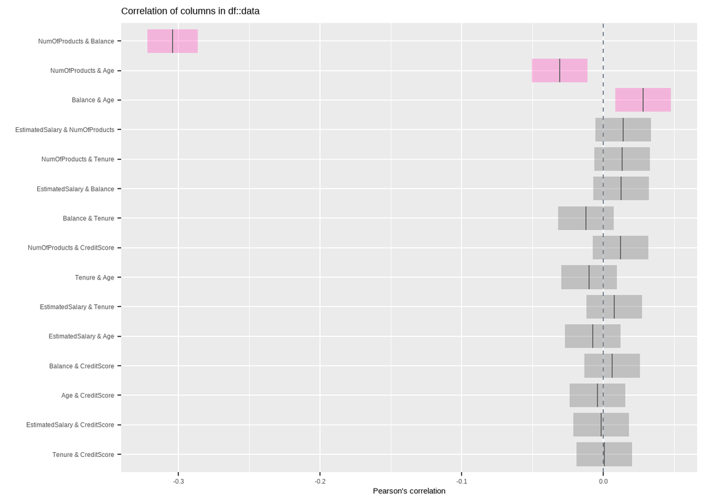

```r
show_plot(inspect_cor(data))
```

No existe correlación alta entre variables. La más destacable es entre el número de productos y el balance, pero no es demasiado alta (negativa y en torno a 0.3)

```r
numericas <- data %>%
  select(where(is.numeric))
```

# 6 VALORES ATÍPICOS U OUTLIERS

Se usa la librería dlookr para el análisis de valores anómalos.

```r
data %>%
    diagnose_outlier(CreditScore, Age,Tenure, Balance, NumOfProducts, EstimatedSalary)%>%
kable("html") %>%
  kable_styling(bootstrap_options = c("bordered","condensed","responsive",'striped'),
                font_size = 12, full_width = F)
```

| variables | outliers_cnt | outliers_ratio | outliers_mean | with_mean | without_mean |
| --- | --- | --- | --- | --- | --- |
| CreditScore | 15 | 0.15 | 361.3333 | 650.5288 | 6.509632e+02 |
| Age | 359 | 3.59 | 69.2702 | 38.9218 | 3.779172e+01 |
| Tenure | 0 | 0.00 | NaN | 5.0128 | 5.012800e+00 |
| Balance | 0 | 0.00 | NaN | 76485.8893 | 7.648589e+04 |
| NumOfProducts | 60 | 0.60 | 4.0000 | 1.5302 | 1.515292e+00 |
| EstimatedSalary | 0 | 0.00 | NaN | 100090.2399 | 1.000902e+05 |

Se puede comprobar que, allá donde existen valores anómalos, las medias entre los datos con outliers y los datos sin outliers son muy similares:

Gráficamente

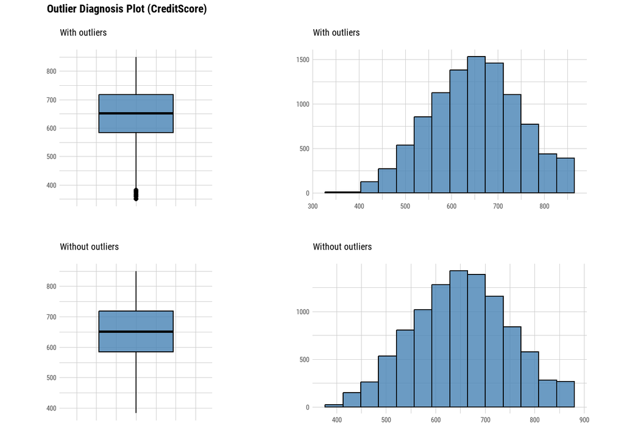

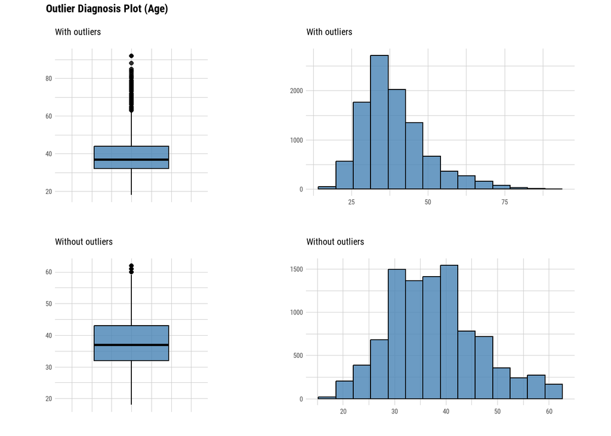

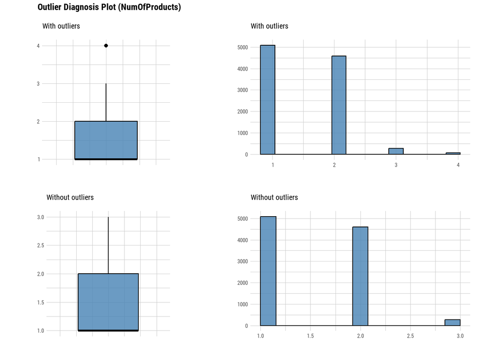

```r
data %>%
    plot_outlier(CreditScore, Age, NumOfProducts)
```

Las distribuciones no cambian demasiado con o sin outliers.

Se puede hacer el mismo análisis cruzando resultados con la variable objetivo

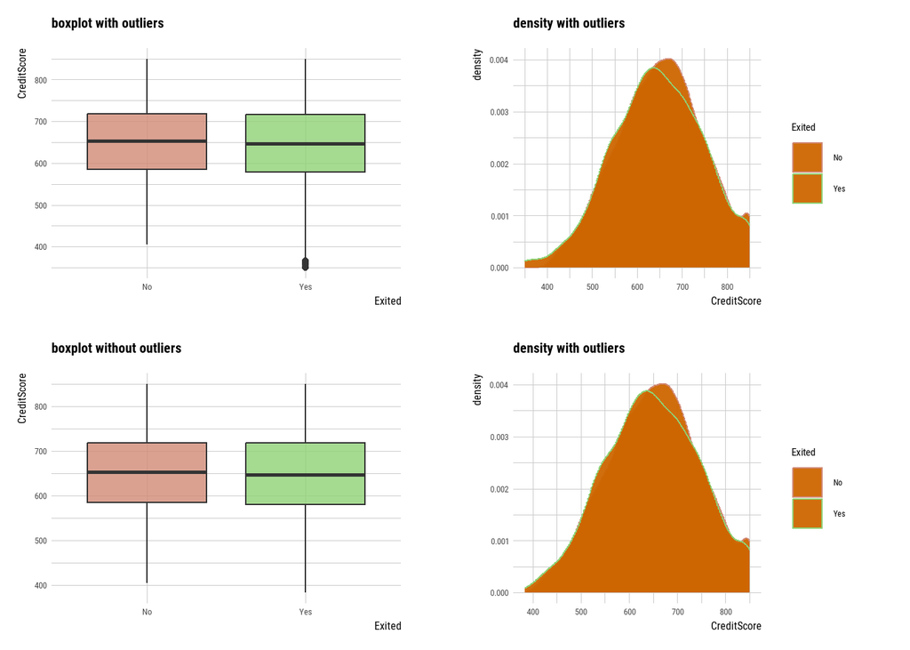

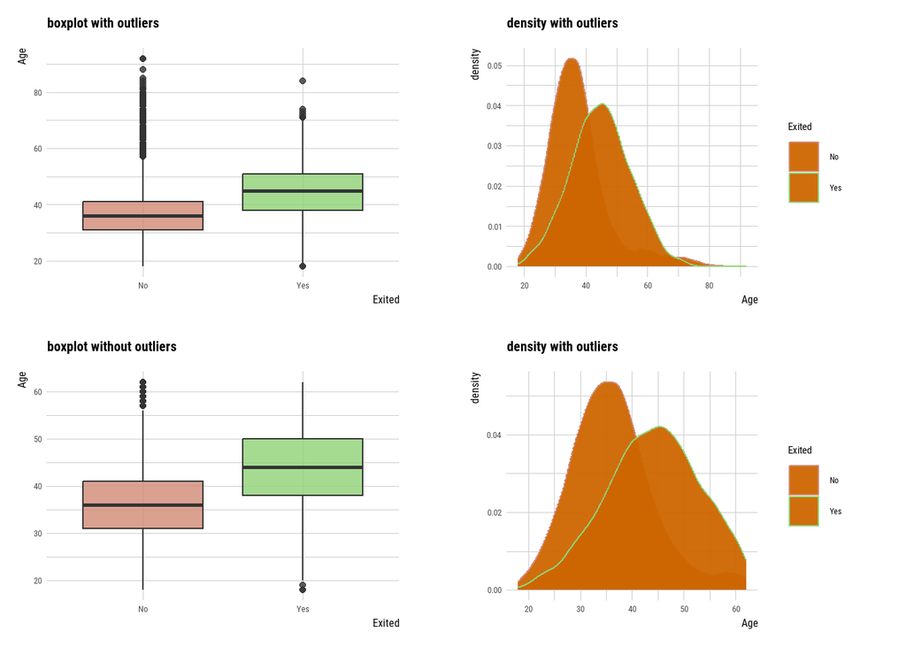

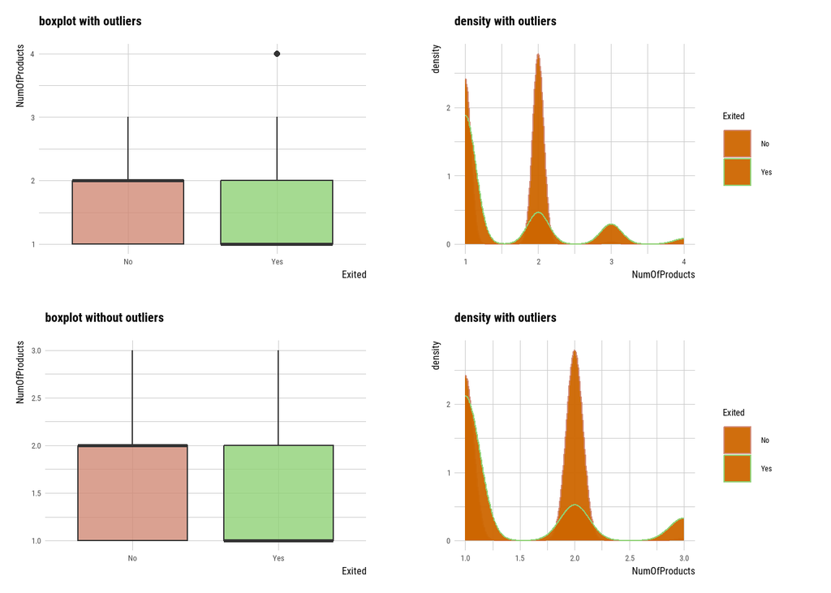

```r
data %>%
  target_by(Exited) %>%
    plot_outlier(CreditScore, Age, NumOfProducts)
```

Tras ver los resultados se puede concluir que trabajar con outliers o sin ellos, en principio, no tendría que alterar sustancialmente los resultados.

Aunque siempre es mejor comprobar los algoritmos y modelos con ambas opciones (con y sin outlier), en este caso usaremos los valores originales sin tratar los valores anómalos.

# 7 BALANCEO DE LA MUESTRA

Como vimos antes, la proporción 80/20 no se considera un desbalanceo excesivo

```r
data %>%
  group_by(Exited) %>%
  summarise(Total = n()) %>%
  kable("html") %>%
  kable_styling(bootstrap_options = c("bordered","condensed","responsive",'striped'),
                full_width = F)
```

| Exited | Total |
| --- | --- |
| No | 7962 |
| Yes | 2038 |

En cualquier caso, se ha decidido realizar el balanceo de la base de datos a través del [método del cubo](https://cude.es/submit-a-manuscript/index.php/CUDE/article/view/15). Es una técnica de submuestreo. Tanto el submuestreo como el sobremuestreo tienen inconvenientes, pero se ha preferido la pérdida de datos a la creación de datos sintéticos y artificiales.

Los modelos se aplicaran a los datos sin balancear y a los datos equilibrados

Antes, se va a realizar un modelo simple para seleccionar las variables indicadoras que integren el submuestreo.

```r
library(MASS)
modelo.glm <- glm(Exited ~ ., data = data, family=binomial)

modelo.stp <- stepAIC(modelo.glm, scope = list(upper = modelo.glm$formula, lower = ~1), direction = "both")
```

```
## Start:  AIC=8588.51
## Exited ~ CreditScore + Geography + Gender + Age + Tenure + Balance +
##     NumOfProducts + HasCrCard + IsActiveMember + EstimatedSalary
##
##                   Df Deviance    AIC
## - HasCrCard        1   8565.1 8587.1
## - EstimatedSalary  1   8565.6 8587.6
## <none>                 8564.5 8588.5
## - Tenure           1   8567.3 8589.3
## - NumOfProducts    1   8569.1 8591.1
## - CreditScore      1   8570.0 8592.0
## - Balance          1   8590.9 8612.9
## - Gender           1   8658.8 8680.8
## - Geography        2   8709.0 8729.0
## - IsActiveMember   1   8938.3 8960.3
## - Age              1   9431.9 9453.9
##
## Step:  AIC=8587.05
## Exited ~ CreditScore + Geography + Gender + Age + Tenure + Balance +
##     NumOfProducts + IsActiveMember + EstimatedSalary
##
##                   Df Deviance    AIC
## - EstimatedSalary  1   8566.2 8586.2
## <none>                 8565.1 8587.1
## - Tenure           1   8567.9 8587.9
## + HasCrCard        1   8564.5 8588.5
## - NumOfProducts    1   8569.6 8589.6
## - CreditScore      1   8570.5 8590.5
## - Balance          1   8591.7 8611.7
## - Gender           1   8659.4 8679.4
## - Geography        2   8709.2 8727.2
## - IsActiveMember   1   8938.5 8958.5
## - Age              1   9432.8 9452.8
##
## Step:  AIC=8586.17
## Exited ~ CreditScore + Geography + Gender + Age + Tenure + Balance +
##     NumOfProducts + IsActiveMember
##
##                   Df Deviance    AIC
## <none>                 8566.2 8586.2
## - Tenure           1   8569.0 8587.0
## + EstimatedSalary  1   8565.1 8587.1
## + HasCrCard        1   8565.6 8587.6
## - NumOfProducts    1   8570.7 8588.7
## - CreditScore      1   8571.7 8589.7
## - Balance          1   8592.9 8610.9
## - Gender           1   8660.8 8678.8
## - Geography        2   8710.4 8726.4
## - IsActiveMember   1   8940.2 8958.2
## - Age              1   9433.5 9451.5
```

```r
modelo.stp$formula
```

```
## Exited ~ CreditScore + Geography + Gender + Age + Tenure + Balance +
##     NumOfProducts + IsActiveMember
```

El siguiente bloque de código es la aplicación del método del cubo para reducir los casos de la clase mayoritaria (Exited = No)

```r
library(sampling)

# Separamos los datos por Exited

data.yes <- data[ data$Exited == 'Yes', ]
data.no <- data[ data$Exited == 'No', ]

# Número de casos Exited = Yes

n.data.yes <- nrow( data.yes )

# Creamos las variables indicadores para cada las variables elegidas del modelo glm

# Vector de unos
UNO = rep( 1, dim( data.no )[ 1 ] )

# Variables cuantitativas
X1 <- data.no[ , c("CreditScore", "Age", "Tenure", "Balance", "NumOfProducts")]

# Variables cualitativas

disjunctive(data.no$Geography) -> X2
colnames(X2) <- levels(data.no$Geography)


disjunctive(data.no$Gender) -> X3
colnames(X3) <- levels(data.no$Gender)


disjunctive(data.no$IsActiveMember) -> X4
colnames(X4) <- levels(data.no$IsActiveMember)


# Matriz de diseño

X <- as.matrix(cbind(UNO, X1, X2, X3, X4))

# Tamaño de la muestra

nB = 2038
nA = nrow(data.no)

# Probabilidades de inclusión en la muestra

pik = rep(nB/nA,nA)

# extraccion de la muestra
set.seed( 123456 )
s = samplecube( X, pik, method = 2, order = 1, comment = FALSE )

muestra.no = cbind(data.no, s)
muestra.no <- subset(data.no, s == 1)
muestra.no$s <- NULL
```

Con esto, se ha reducido 7962 registros donde Exited = No a 2038 registros.

Se va a comprobar la calidad de la muestra (desviación absoluta y relativa entre datos originales y el submuestreo)

```r
Totales <- apply(X, 2, sum)
Horvitz.Thompson <- apply(X * s / pik, 2, sum)
calidad <- cbind.data.frame(Totales, Horvitz.Thompson)
calidad$Desv.Abs. <- round(calidad$Totales - calidad$Horvitz.Thompson, 2)
calidad$Desv.Rel. <- round((calidad$Totales / calidad$Horvitz.Thompson - 1) *100, 2)
print(as.matrix.data.frame(calidad))
```

```
##                 Totales Horvitz.Thompson Desv.Abs. Desv.Rel.
## UNO                7962     7.962000e+03      0.00      0.00
## CreditScore     5189933     5.189255e+06    678.01      0.01
## Age              297843     2.977702e+05     72.79      0.02
## Tenure            40071     4.007566e+04     -4.66     -0.01
## Balance       579177781     5.788926e+08 285141.10      0.05
## NumOfProducts     12295     1.228680e+04      8.20      0.07
## France             4203     4.203686e+03     -0.69     -0.02
## Germany            1695     1.691632e+03      3.37      0.20
## Spain              2064     2.066682e+03     -2.68     -0.13
## Female             3404     3.402798e+03      1.20      0.04
## Male               4558     4.559202e+03     -1.20     -0.03
## No                 3546     3.547348e+03     -1.35     -0.04
## Yes                4416     4.414652e+03      1.35      0.03
```

Verificación de calidad de la muestra a través de gráficos (solo Balance y Tenure a modo de ejemplo):

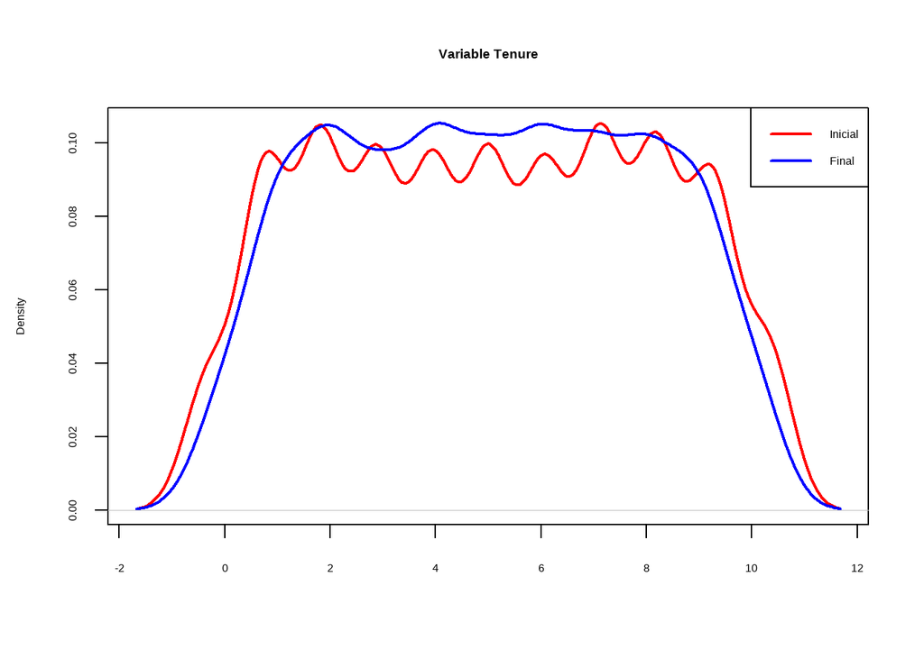

```r
# muestra inicial vs muestra balanceada


tenure_ini <- density(data.no$Tenure)

tenure_fin  <- density(muestra.no$Tenure)

plot(tenure_ini, lwd = 2, col = "red", xlab = "", ylab = "", xaxt = "n", yaxt = "n", main = "")

par(new=T)

plot(tenure_fin, lwd = 2, col = "blue", xlab = "", main = "Variable Tenure")
legend(x = "topright", legend = c("Inicial", "Final"), lty = c(1, 1), col = c("red", "blue"), lwd = 2)
```

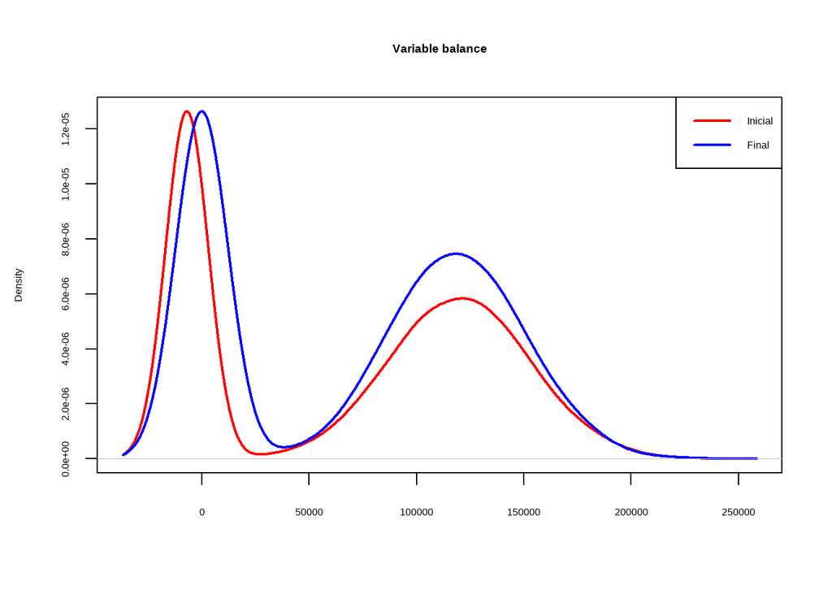

```r
# muestra inicial vs muestra balanceada


balance_ini <- density(data.no$Balance)

balance_fin  <- density(muestra.no$Balance)

plot(balance_ini, lwd = 2, col = "red", xlab = "", ylab = "", xaxt = "n", yaxt = "n", main = "")

par(new=T)

plot(balance_fin, lwd = 2, col = "blue", xlab = "", main = "Variable balance")
legend(x = "topright", legend = c("Inicial", "Final"), lty = c(1, 1), col = c("red", "blue"), lwd = 2)
```

Se generan los datos balanceados

```r
muestra.yes <- data[data$Exited == "Yes",]

# Data frame resultante
data_balanced <- rbind( muestra.yes, muestra.no)

# Tabla de frecuencias de variable dependiente. Como vemos, los datos están ya balanceados
table(data_balanced$Exited)
```

```
##
##   No  Yes
## 2038 2038
```

# 8 ESCALADO Y CENTRADO DE VARIABLES NUMERICAS

Los rangos de las variables numéricas son muy diferentes por lo que quizás convendría escalar y centrar los datos.

```r
data_scale <- data %>%
  mutate(across(where(is.numeric), scale))

data_balanced_scale <- data_balanced %>%
  mutate(across(where(is.numeric), scale))
```

Un vistazo al resultado

```r
head(data_scale, 5) %>%
  kable() %>%
  kable_styling(bootstrap_options = 'striped', font_size = 12, full_width = F) %>%
  scroll_box(width = "100%")
```

| CreditScore | Geography | Gender | Age | Tenure | Balance | NumOfProducts | HasCrCard | IsActiveMember | EstimatedSalary | Exited |
| --- | --- | --- | --- | --- | --- | --- | --- | --- | --- | --- |
| -0.3262051 | France | Female | 0.293502747 | -1.041708 | -1.2257864 | -0.9115379 | Yes | Yes | 0.0218854 | Yes |
| -0.4400140 | Spain | Female | 0.198153924 | -1.387468 | 0.1173442 | -0.9115379 | No | Yes | 0.2165229 | No |
| -1.5367173 | France | Female | 0.293502747 | 1.032856 | 1.3329867 | 2.5269303 | Yes | No | 0.2406749 | Yes |
| 0.5014956 | France | Female | 0.007456278 | -1.387468 | -1.2257864 | 0.8076962 | No | No | -0.1089125 | No |
| 2.0637806 | Spain | Female | 0.388851570 | -1.041708 | 0.7856886 | -0.9115379 | Yes | Yes | -0.3652575 | No |

```r
head(data_balanced_scale, 5) %>%
  kable() %>%
  kable_styling(bootstrap_options = 'striped', font_size = 12, full_width = F) %>%
  scroll_box(width = "100%")
```

| CreditScore | Geography | Gender | Age | Tenure | Balance | NumOfProducts | HasCrCard | IsActiveMember | EstimatedSalary | Exited |
| --- | --- | --- | --- | --- | --- | --- | --- | --- | --- | --- |
| -0.30075353 | France | Female | 0.08258765 | -1.0304399 | -1.3383583 | -0.7565980 | Yes | Yes | 0.03611924 | Yes |
| -1.49019943 | France | Female | 0.08258765 | 1.0414534 | 1.2704567 | 2.2143976 | Yes | No | 0.25341477 | Yes |
| -0.03643222 | Spain | Male | 0.26970675 | 1.0414534 | 0.5203809 | 0.7288998 | Yes | No | 0.87209352 | Yes |
| -2.77114116 | Germany | Female | -1.13368652 | -0.3398088 | 0.5414748 | 3.6998954 | Yes | No | 0.34693394 | Yes |
| 0.04489741 | Germany | Male | 1.57954047 | -1.3757554 | 0.8283375 | -0.7565980 | Yes | No | -1.62608161 | Yes |

En los modelos se usarán los datos escalados

# 9 CREACIÓN DE DATASETS FINALES PARA MODELOS

Antes de aplicar modelos y para finalizar el preprocesado, se van a generar los ficheros de datos resultantes.

En los modelos se usan unas funciones facilitadas por el equipo docente del master cursado. Para el correcto uso de dichas funciones la variable objetivo debe ser renombrada (variable Y)

```r
colnames(data_scale)[11]<-"y"
colnames(data_balanced_scale)[11]<-"y"
```

Se generan archivos csv para usarlos en la segunda parte del proyecto:

```r
# write.csv(data_scale, file = 'data_preproc/data_scale.csv',row.names = FALSE)

# write.csv(data_balanced_scale, file = 'data_preproc/data_balanced_scale.csv',row.names = FALSE)
```